# P300 Experiment

# Results

## Participants

5 undergraduate students at Vassar College completed the experiment.

## Behavioral

Participants were asked to count the number of oddball stimuli and report the total at the end of each block. Each block contained 50 oddballs. On the whole, participants were very accurate. The largest error within an individual block across all participants was 2. The average error per block was 0.467, *SD*=0.64.

## EEG

### Segments

Across the three blocks of the experiment, there were a total of 600 blue circle events, 75 orange circle events, and 75 purple circle events. On average, subjects had 498.8 good segments for blue circles (*SD* = 79.4), 62.2 good segments for orange circles (*SD* = 11.5), and 60.8 good segments for purple circles (*SD* = 11.9). The minimum number of good segments in any condition across all subjects was 41.

### ERPs

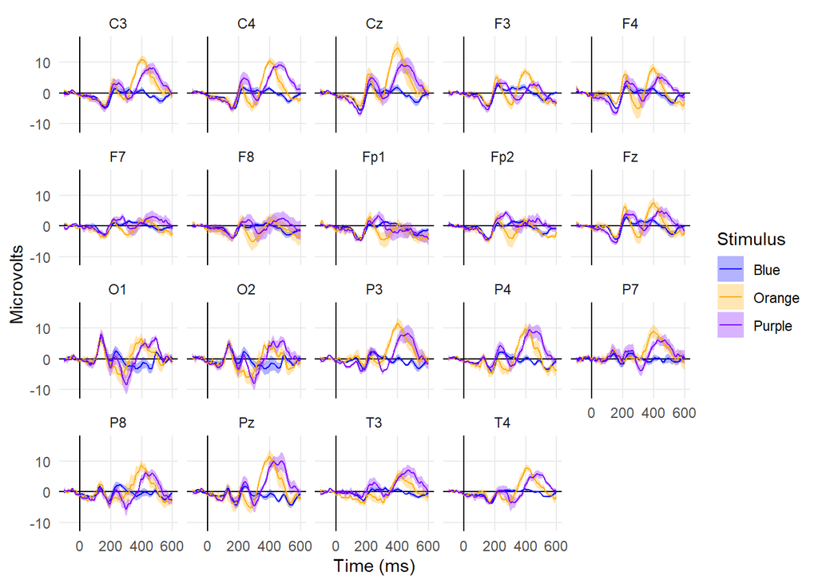

Grand Average ERPs for all electrodes.

### Difference waves

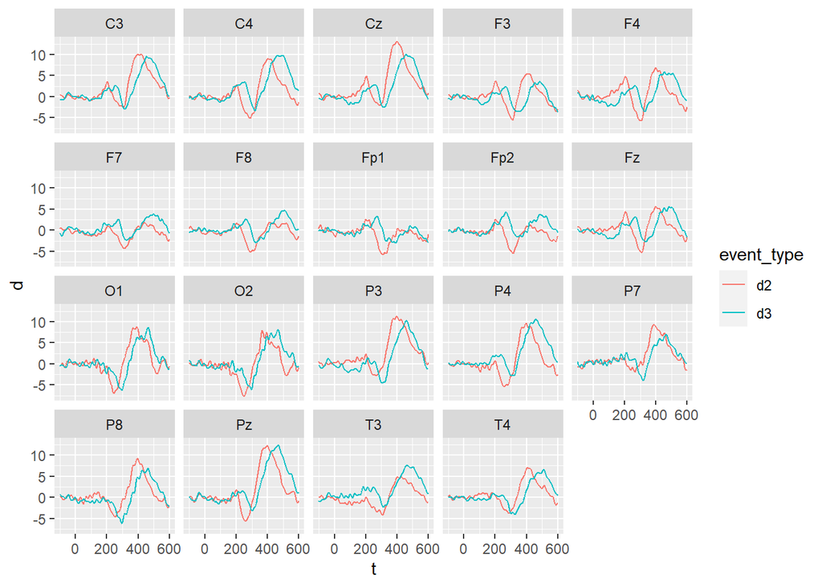

```r
difference.waves <- grand.average.waveforms %>%
  pivot_wider(id_cols=c(electrode, t), names_from=event_type, values_from=m) %>%
  mutate(d2 = `2` - `1`, d3 = `3` - `1`) %>%
  select(electrode, t, d2, d3) %>%
  pivot_longer(c("d2", "d3"), names_to="event_type", values_to="d")

ggplot(difference.waves, aes(x=t, y=d, color=event_type)) +
  facet_wrap(.~electrode) +
  geom_line()
```

### Statistical Analysis; ANOVAs

Pick time window

Calculate averages per subject for each event type

1-way ANOVA on event type

t-test on 2v2